# Variação do IBOVESPA por Governo Federal

#### Wilson Freitas

01/01/2017

Categoria: [finance](https://wilsonfreitas.github.io/category/finance.html)

Tags: [python](https://wilsonfreitas.github.io/tag/python.html) [visualization](https://wilsonfreitas.github.io/tag/visualization.html) [pandas](https://wilsonfreitas.github.io/tag/pandas.html)

```python
import numpy as np
import matplotlib.pyplot as plt
import pandas as pd
pd.options.display.mpl_style = 'default'
import Quandl
%pylab inline
```

O objetivo aqui é analisar a variação do IBOVESPA nos períodos dos governos federais desde a estabilização da moeda, o primeiro governo do FHC. Adicionalmente vou considerar a variação do índice deflacionado para entender o impacto da inflação na economia nestes períodos. Já calculei o IBOVESPA deflacionado no [post](https://wilsonfreitas.github.io/posts/no-brasil-ate-o-passado-e-duvidoso.html). As contas são simples:

- calcular os retornos do IBOVESPA mensais nos governos federais
- calcular estes retornos descontados da inflação (uso o IPCA)
- agrupar os retornos por períodos (governos federais) e calcular os retornos acumulados
- calcular os retornos anualizado nos períodos para facilitar a comparação entre governos com períodos diferentes

Vou começar baixando as séries de IPCA e IBOVESPA (mensal) via Quandl (veja como fazer isso no [post](https://wilsonfreitas.github.io/posts/quandl-uma-otima-forma-de-obter-dados-estruturados-em-python.html)).

```python
data = Quandl.get(["BCB/433", "BCB/7845"], trim_start="1994-12-01")
data.columns = ["IPCA", "IBOVESPA"]
data.head()
```

| Date | IPCA | IBOVESPA |
| --- | --- | --- |
| 1994-12-31 | 1.71 | 43539 |
| 1995-01-31 | 1.70 | 38850 |
| 1995-02-28 | 1.02 | 32708 |
| 1995-03-31 | 1.55 | 29789 |
| 1995-04-30 | 2.43 | 38137 |

O primeiro ponto da série é 1994-12-31, que representa o fim do Governo Itamar Franco, pois dessa forma é possível calcular os retornos desde o primeiro mês do governo FHC.

A seguir os retornos do índice são calculados (`IBOVESPA_D`) e deflacionados (`IBOVESPA_D_DEFL`) ( já vimos como calcular os retornos com pandas no [post](https://wilsonfreitas.github.io/posts/calculando-retornos-financeiros-com-pandas.html)).

```python
data["IBOVESPA_D"] = data["IBOVESPA"].diff()/data["IBOVESPA"].shift(1)
data["IBOVESPA_D_DEFL"] = (1 + data["IBOVESPA_D"])/(1 + data["IPCA"]/100) - 1
data.head()
```

| Date | IPCA | IBOVESPA | IBOVESPA_D | IBOVESPA_D_DEFL |
| --- | --- | --- | --- | --- |
| 1994-12-31 | 1.71 | 43539 | NaN | NaN |
| 1995-01-31 | 1.70 | 38850 | -0.107697 | -0.122612 |
| 1995-02-28 | 1.02 | 32708 | -0.158095 | -0.166596 |
| 1995-03-31 | 1.55 | 29789 | -0.089244 | -0.103145 |
| 1995-04-30 | 2.43 | 38137 | 0.280238 | 0.249866 |

```python
data.tail()
```

| Date | IPCA | IBOVESPA | IBOVESPA_D | IBOVESPA_D_DEFL |
| --- | --- | --- | --- | --- |
| 2016-07-31 | 0.52 | 57308 | 0.112215 | 0.106462 |
| 2016-08-31 | 0.44 | 57901 | 0.010348 | 0.005922 |
| 2016-09-30 | 0.08 | 58367 | 0.008048 | 0.007242 |
| 2016-10-31 | 0.26 | 64924 | 0.112341 | 0.109456 |
| 2016-11-30 | 0.18 | 61906 | -0.046485 | -0.048198 |

Como o objetivo é agrupar os dados pelos períodos dos governos federais, vou criar uma função `governo` que recebe uma data e retorna o governo vigente. Em seguida eu aplico essa função ao índice do `DataFrame` e crio uma coluna chamada `GOVERNO`.

```python
def governo(data):
    data = data.date()
    if data >= datetime.date(1995, 1, 1) and data <= datetime.date(1998, 12, 31):
        return 'FHC 1'
    elif data >= datetime.date(1999, 1, 1) and data <= datetime.date(2002, 12, 31):
        return 'FHC 2'
    elif data >= datetime.date(2003, 1, 1) and data <= datetime.date(2006, 12, 31):
        return 'LULA 1'
    elif data >= datetime.date(2007, 1, 1) and data <= datetime.date(2010, 12, 31):
        return 'LULA 2'
    elif data >= datetime.date(2011, 1, 1) and data <= datetime.date(2014, 12, 31):
        return 'DILMA 1'
    elif data >= datetime.date(2015, 1, 1) and data < datetime.date(2016, 5, 12):
        return 'DILMA 2'
    elif data >= datetime.date(2016, 5, 12) and data <= datetime.date(2016, 12, 31):
        return 'TEMER'
    else:
        return None

data['GOVERNO'] = data.index.map(governo)
```

Agora eu agrupo (`groupby`) pela `GOVERNO` e sumarizo os dados com a função `aggregate` calculando o retorno acumulado em cada período de governo federal.

```python
data_gov = data.groupby('GOVERNO')
```

Vou calcular o retorno acumulado das colunas `IBOVESPA_D` e `IBOVESPA_D_DEFL` passando para a função `aggregate` a função de retorno acumulado abaixo:

$$ 100 \cdot \left( \left[ \prod^{n}_{i=1} \left(1 + x_i \right) \right] - 1 \right) $$

que realiza o produtório do fator de captalização dos retornos e multiplico o resultado por 100 para obter o número em percentual.

```python
data_gov_agg = data_gov[['IBOVESPA_D', 'IBOVESPA_D_DEFL']].aggregate(lambda x: 100*(np.prod(1 + x) - 1))
data_gov_agg
```

| GOVERNO | IBOVESPA_D | IBOVESPA_D_DEFL |
| --- | --- | --- |
| DILMA 1 | -27.843992 | -43.199362 |
| DILMA 2 | 7.804907 | -5.655127 |
| FHC 1 | -84.418567 | -89.138794 |
| FHC 2 | 66.096698 | 18.739626 |
| LULA 1 | 294.684061 | 207.855809 |
| LULA 2 | 55.833877 | 27.511680 |
| TEMER | 14.832128 | 11.881034 |

As colunas `IBOVESPA_D` e `IBOVESPA_D_DEFL` representam os retornos totais nos períodos dos governos federais. Já é possível notar duas coisas: o primeiro governo do Lula apresenta um retorno muito grande e os governos estão fora de ordem cronológica. Vamos colocar os governos em ordem cronológica para visualizar os dados de forma coerente. Para ordenar os dados por governos de forma cronológica eu vou criar a função `sort_by_governo` que recebe um `DataFrame` e o retorna ordenado.

```python
def sort_by_governo(dx):
    governos = ['FHC 1', 'FHC 2', 'LULA 1', 'LULA 2', 'DILMA 1', 'DILMA 2', 'TEMER']
    mapping = {gov: i for i, gov in enumerate(governos)}
    key = dx.index.map(lambda x: mapping[x])
    return dx.iloc[key.argsort()]

data_gov_agg = sort_by_governo(data_gov_agg)
data_gov_agg
```

| GOVERNO | IBOVESPA_D | IBOVESPA_D_DEFL |
| --- | --- | --- |
| FHC 1 | -84.418567 | -89.138794 |
| FHC 2 | 66.096698 | 18.739626 |
| LULA 1 | 294.684061 | 207.855809 |
| LULA 2 | 55.833877 | 27.511680 |
| DILMA 1 | -27.843992 | -43.199362 |
| DILMA 2 | 7.804907 | -5.655127 |
| TEMER | 14.832128 | 11.881034 |

Com os dados ordenados vamos visualizá-los em um gráfico de barras.

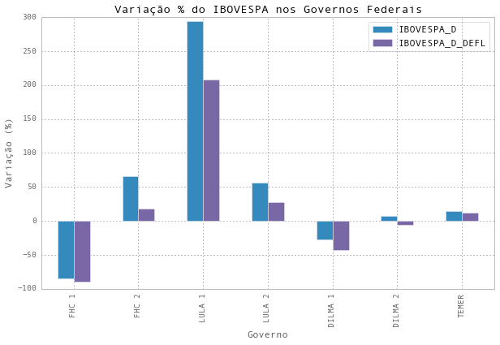

```python
ax = data_gov_agg[['IBOVESPA_D', 'IBOVESPA_D_DEFL']].plot(kind='bar', figsize=(10,6),
                                                          title="Variação % do IBOVESPA nos Governos Federais")
ax.set_xlabel("Governo")
ax.set_ylabel("Variação (%)");
```

É possível observar diversas coisas, vou listar os pontos que mais me chamaram a atenção:

- A inflação no governo DILMA 2 comeu todo o retorno entrege pelo IBOVESPA
- O pior período para o IBOVESPA foi o primeiro governo do FHC
- O governo LULA 1 apresentou um retorno espetacular
- Os governos FHC 2 e LULA 2 apresentam retornos semelhantes, apesar da inflação ser maior em FHC 2 e LULA 2 contempla a crise *Sub Prime*

No entanto, os governos `DILMA 2` e `TEMER` possuem durações diferentes dos demais, portanto vamos calcular os retornos anualizados para cada governo para facilitar a comparação. Apesar de que governos com maiores durações sofrem mais com a volatilidade do que governos mais curtos, que por outro lado tem menos tempo de recuperação caso recessões ocorram.

Para calcular os retornos anualizados vou fazer uma contagem da quantidade de meses de cada governo. Faço isso contando a quantidade de dados em cada grupo `GOVERNO` e crio a coluna `Meses`.

```python
data_gov_agg['Meses'] = data_gov['GOVERNO'].count()
data_gov_agg
```

| GOVERNO | IBOVESPA_D | IBOVESPA_D_DEFL | Meses |
| --- | --- | --- | --- |
| FHC 1 | -84.418567 | -89.138794 | 48 |
| FHC 2 | 66.096698 | 18.739626 | 48 |
| LULA 1 | 294.684061 | 207.855809 | 48 |
| LULA 2 | 55.833877 | 27.511680 | 48 |
| DILMA 1 | -27.843992 | -43.199362 | 48 |
| DILMA 2 | 7.804907 | -5.655127 | 16 |
| TEMER | 14.832128 | 11.881034 | 7 |

Os retornos anualizados são calculados a partir dos retornos do período, de acordo com a fórmula:

$$ \left( \left( 1 + r \right)^{12/n} - 1 \right) \cdot 100 $$

onde $r$ são as taxas de retorno e $n$ é a quantidade de meses de cada governo.

```python
data_gov_agg['IBOVESPA_D_anual'] = ((1 + data_gov_agg['IBOVESPA_D']/100)**(12./data_gov_agg['Meses']) - 1)*100
data_gov_agg['IBOVESPA_D_DEFL_anual'] = ((1 + data_gov_agg['IBOVESPA_D_DEFL']/100)**(12./data_gov_agg['Meses']) - 1)*100
data_gov_agg
```

| GOVERNO | IBOVESPA_D | IBOVESPA_D_DEFL | Meses | IBOVESPA_D_anual | IBOVESPA_D_DEFL_anual |
| --- | --- | --- | --- | --- | --- |
| FHC 1 | -84.418567 | -89.138794 | 48 | -37.172201 | -42.592385 |
| FHC 2 | 66.096698 | 18.739626 | 48 | 13.524670 | 4.387602 |
| LULA 1 | 294.684061 | 207.855809 | 48 | 40.949129 | 32.460637 |
| LULA 2 | 55.833877 | 27.511680 | 48 | 11.728886 | 6.264326 |
| DILMA 1 | -27.843992 | -43.199362 | 48 | -7.834555 | -13.186292 |
| DILMA 2 | 7.804907 | -5.655127 | 16 | 5.798351 | -4.272056 |
| TEMER | 14.832128 | 11.881034 | 7 | 26.755219 | 21.222301 |

Agora vamos visualizar os dados.

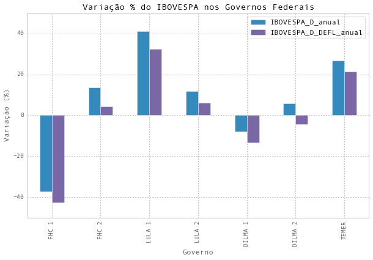

```python
ax = data_gov_agg[['IBOVESPA_D_anual', 'IBOVESPA_D_DEFL_anual']].plot(kind='bar', figsize=(10,6),
                                                                      title="Variação % do IBOVESPA nos Governos Federais")
ax.set_xlabel("Governo")
ax.set_ylabel("Variação (%)");
```

Os dados anualizados produzem uma mudança de escala significativa onde o governo `LULA 1` ainda apresenta um retorno execepcional, entretanto o governo `TEMER` aparece em destaque. O governo `FHC 1` continua liderando como pior caso e o impacto da inflação no governo `DILMA 2` ganha destaque.

## Conclusão

A tabela já apresentava os resultados de maneira clara, mas os gráficos são capazes de tornar a compreensão quase que instantânea. A análise deflacionada nos permiter observar que nos períodos de crescimento a figura não é tão boa assim. É importante ficar claro que o IPCA é uma média muito geral, e a inflação medida localmente varia. Estes resultados podem ser bem piores em algumas capitais.

Um gráfico que faltou foi a inflação acumulada em cada período. Vou fazê-la aqui anualizada para facilitar a interpretação.

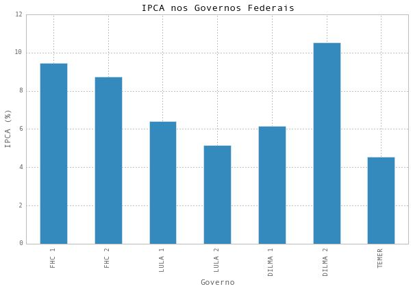

```python
data_infl = data_gov['IPCA'].aggregate(lambda x: 100*(np.prod(1 + x/100)**(12./len(x)) - 1))
data_infl = sort_by_governo(data_infl)
ax = data_infl.plot(kind='bar', figsize=(10,6),
                    title="IPCA nos Governos Federais")
ax.set_xlabel("Governo")
ax.set_ylabel("IPCA (%)");
```

Fica aí pra ajudar na interpretação dos demais resultados.

De qualquer formar vimos que é simples fazer uma análise interessante com Python e apresentar os resultados de forma clara e simples. Este é o poder dos dados abertos! O Quandl é muito bom, mas precisamos de mais ferramentas de dados estrutuados com informações do Brasil.

## Comments

© Wilson Freitas 2015-2018

Powered by Pelican